# Düzenlileştirme

(İktisatçılar İçin) Makine Öğrenmesi (TEK-ES-2021)

Prof. Dr. Hüseyin Taştan

Yıldız Teknik Üniversitesi

Haziran 2021

# 1 Ridge Regresyonu

`glmnet` paketiyle Ridge ve LASSO modelleri tahmin edilebilir. Bu paketteki temel fonksiyon olan `glmnet()` sadece vektör ve matrisleri girdi olarak kabul etmektedir. Bu nedenle şimdiye kadar kullandığımız `y ~ x` regresyon modeli yapısını kullanmayacağız. Önce çıktı değişkenini içeren bir `y` vektörü ve kestirim değişkenlerini içeren bir `x` matrisi oluşturacağız. Verilerde eğer varsa kayıp gözlemler silinmelidir. `x` ve `y`’nin oluşturulmasında `model.matrix()` fonksiyonu kullanılabilir. Örnek olarak `Credit` verilerinde `Balance` değişkeni için bir doğrusal regresyon modeli kurmak istediğimizi düşünelim:

```r
library(ISLR)
x <- model.matrix(Balance ~ . -ID, Credit)[,-1]
y <- Credit$Balance
```

`x` matrisi birler sütununu içermez:

```r
head(x)
```

```
##    Income Limit Rating Cards Age Education GenderFemale StudentYes MarriedYes
## 1  14.891  3606    283     2  34        11            0          0          1
## 2 106.025  6645    483     3  82        15            1          1          1
## 3 104.593  7075    514     4  71        11            0          0          0
## 4 148.924  9504    681     3  36        11            1          0          0
## 5  55.882  4897    357     2  68        16            0          0          1
## 6  80.180  8047    569     4  77        10            0          0          0
##   EthnicityAsian EthnicityCaucasian
## 1              0                  1
## 2              1                  0
## 3              1                  0
## 4              1                  0
## 5              0                  1
## 6              0                  1
```

`model.matrix()` fonksiyonu kategorik değişkenleri otomatik olarak kukla değişkenlere dönüştürmektedir. `glmnet()` sadece nicel değişkenleri girdi olarak kabul eder.

`glmnet()` fonksiyonunun üçüncü girdisi, `alpha`, hangi modelin tahmin edileceğini belirler. **Ridge** regresyonu için `alpha=0`, **LASSO** için `alpha=1` değeri girilmelidir. Elastik net için ara değerler girilebilir.

Ridge modelini tahmin edelim:

```r
library(glmnet)
grid <- 10^seq(10,-2,length=100)
ridge.mod <- glmnet(x, y, alpha=0, lambda=grid)
```

Ayarlama parametresi $\lambda=10^{10}$ ile  
$\lambda=10^{-2}$ arasında değerler almaktadır (istenirse `glmnet()`’in default değerleri de kullanılabilir). Bu grid değerleri tüm olanaklı modelleri kapsamaktadır. `glmnet()` değişkenleri otomatik olarak standardize eder.

Her bir $\lambda$ değeri için elimizde bir katsayı kümesi vardır:

```r
dim(coef(ridge.mod))
```

```
## [1]  12 100
```

```r
ridge.mod$lambda[50]
```

```
## [1] 11497.57
```

```r
coef(ridge.mod)[,50]
```

```
##        (Intercept)             Income              Limit             Rating
##      443.882328225        0.207297549        0.006255511        0.093529429
##              Cards                Age          Education       GenderFemale
##        1.094782827       -0.007423108       -0.036491175        0.727221775
##         StudentYes         MarriedYes     EthnicityAsian EthnicityCaucasian
##       15.224286108       -0.273927934       -0.323636288       -0.088984490
```

Yukarıda $\lambda = 11497.57$ değerine karşılık gelen katsayılar listelendi. Bunu daha küçük bir `lambda` değeriyle karşılaştıralım:

```r
ridge.mod$lambda[60]
```

```
## [1] 705.4802
```

```r
coef(ridge.mod)[,60]
```

```
##        (Intercept)             Income              Limit             Rating
##        11.21325341         0.47047426         0.04709688         0.70328171
##              Cards                Age          Education       GenderFemale
##        10.00746444        -0.54061006         0.01398463         4.61657214
##         StudentYes         MarriedYes     EthnicityAsian EthnicityCaucasian
##       156.68825813        -6.12237541         0.62039885         1.43859125
```

Katsayıların mutlak olarak daha büyük olduğuna dikkat ediniz.

Ridge tahmininden sonra `predict()` komutunu kullanarak verilmiş bir `\lambda` için katsayıları görebilir ve kestirimleri oluşturabiliriz. Örneğin $\lambda=5$ için katsayılar:

```r
predict(ridge.mod, s=5, type = "coefficients")
```

```
## 12 x 1 sparse Matrix of class "dgCMatrix"
##                               1
## (Intercept)        -482.0908534
## Income               -7.3786800
## Limit                 0.1394724
## Rating                1.8078713
## Cards                14.6369432
## Age                  -0.6828495
## Education            -0.8464725
## GenderFemale         -9.7286964
## StudentYes          417.5009710
## MarriedYes          -10.5373764
## EthnicityAsian       17.2728709
## EthnicityCaucasian   10.1168219
```

$\lambda=0$ için katsayılar:

```r
predict(ridge.mod, s=0, type = "coefficients")
```

```
## 12 x 1 sparse Matrix of class "dgCMatrix"
##                               1
## (Intercept)        -484.5793031
## Income               -7.8000494
## Limit                 0.1762025
## Rating                1.3552800
## Cards                16.6658896
## Age                  -0.6161868
## Education            -1.0432920
## GenderFemale        -10.6556451
## StudentYes          425.0180442
## MarriedYes           -9.0413285
## EthnicityAsian       17.1847593
## EthnicityCaucasian   10.1487876
```

Bunu OLS ile kıyaslayınız:

```r
coefficients(lm(Balance ~ . -ID, data=Credit))
```

```
##        (Intercept)             Income              Limit             Rating
##       -479.2078706         -7.8031018          0.1909067          1.1365265
##              Cards                Age          Education       GenderFemale
##         17.7244836         -0.6139088         -1.0988553        -10.6532477
##         StudentYes         MarriedYes     EthnicityAsian EthnicityCaucasian
##        425.7473595         -8.5339006         16.8041792         10.1070252
```

Şimdi verileri eğitim ve test olmak üzere ikiye ayıralım ve ridge regresyonunun test hatasını tahmin edelim.

```r
# eğitim ve test kümeleri
set.seed(1)
train <- sample(1:nrow(x), nrow(x)/2)
test <- (-train)
y.test <- y[test]
```

Sadece eğitim verilerini kullanarak ridge regresyonunu tahmin edelim. Test kestirimlerini $\lambda=5$ için hesaplayacağız. `predict()` fonksiyonunda `type="coefficients"` yerine `newx` girdisini kullanacağız:

```r
ridge.mod <- glmnet(x[train,], y[train], alpha=0, lambda=grid, thresh=1e-12)
ridge.pred <- predict(ridge.mod, s=5, newx=x[test,])
mean((ridge.pred - y.test)^2)
```

```
## [1] 10364.53
```

Test MSE 10364.53 olarak tahmin edildi. Kıyaslamak için hiç `x` değişkeninin olmadığı (yani en iyi kestirimin `y`’nin aritmetik ortalaması olduğu) bir model için MSE değerini hesaplayalım:

```r
mean((mean(y[train]) - y.test)^2)
```

```
## [1] 194031
```

`lambda` için çok büyük değer kullansaydık aynı değeri elde ederdik:

```r
ridge.pred <- predict(ridge.mod, s=1e10, newx=x[test,])
mean((ridge.pred-y.test)^2)
```

```
## [1] 194030.9
```

$\lambda=5$ ile tahmin ettiğimiz model sadece sabitin olduğu boş modele göre daha düşük bir test MSE değeri verdi. Acaba OLS tahminine kıyasla ridge regresyonu kurmanın bir avantajı var mı? $\lambda=0$ değerinin OLS sonucunu vereceğini biliyoruz:

```r
ridge.pred <- predict(ridge.mod, s=0, newx=x[test,], exact=T, x=x[train,], y=y[train])
mean((ridge.pred - y.test)^2)
```

```
## [1] 10690.72
```

Bu sonuca göre ridge test hatası daha düşüktür. Katsayıları karşılaştıralım: :

```r
lm(y ~ x, subset = train)
```

```
##
## Call:
## lm(formula = y ~ x, subset = train)
##
## Coefficients:
##         (Intercept)              xIncome               xLimit
##           -442.7079              -7.6232               0.2617
##             xRating               xCards                 xAge
##              0.1148              20.8071              -1.1848
##          xEducation        xGenderFemale          xStudentYes
##             -0.1258             -10.8190             426.2268
##         xMarriedYes      xEthnicityAsian  xEthnicityCaucasian
##             -8.5852              -2.0410              -3.8183
```

```r
predict(ridge.mod, s=0, exact=T, type="coefficients", x=x[train,], y=y[train])[1:12,]
```

```
##        (Intercept)             Income              Limit             Rating
##       -442.7301801         -7.6232170          0.2616904          0.1156010
##              Cards                Age          Education       GenderFemale
##         20.8029874         -1.1848037         -0.1256060        -10.8190972
##         StudentYes         MarriedYes     EthnicityAsian EthnicityCaucasian
##        426.2232453         -8.5865463         -2.0374014         -3.8166763
```

Yukarıdaki hesaplamalarda keyfi bir $\lambda$ değeri kullandık. Bu ayarlama parametresinin optimal seçiminde çapraz geçerleme yöntemini kullanabiliriz. Daha önce gördüğümüz `cv.glmnet()` fonksiyonunu bu amaçla kullanabiliriz. (default K=10)

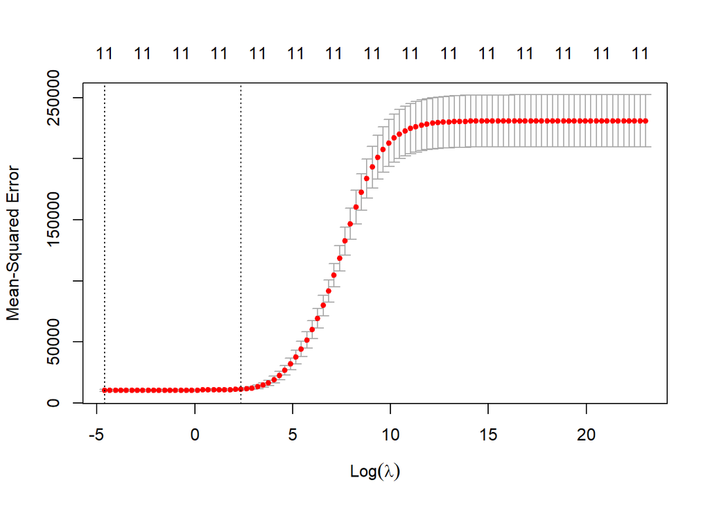

```r
set.seed(1)
cv.out <- cv.glmnet(x[train,], y[train], alpha=0, lambda=grid)
plot(cv.out)
```

```r
bestlam <- cv.out$lambda.min
bestlam
```

```
## [1] 0.01
```

En küçük çapraz geçerleme test hatasını veren değer $\lambda=0.01$. Buna karşılık gelen test MSE değeri:

```r
ridge.pred <- predict(ridge.mod, s=bestlam, newx=x[test,])
mean((ridge.pred - y.test)^2)
```

```
## [1] 10679.98
```

Tercih edilen model:

```r
out <- glmnet(x, y, alpha=0)
predict(out, type="coefficients", s=bestlam)[1:12,]
```

```
##        (Intercept)             Income              Limit             Rating
##       -400.8600617         -5.1751854          0.1144898          1.6607396
##              Cards                Age          Education       GenderFemale
##         15.8061272         -0.9565674         -0.4740526         -4.8551984
##         StudentYes         MarriedYes     EthnicityAsian EthnicityCaucasian
##        381.6895970        -12.0976162         13.1298333          9.1146561
```

Dikkat edilirse hiç bir katsayı tam olarak 0 değildir. Ridge regresyonu değişken seçimi yapmaz. Bu amaçla LASSO kullanılabilir.

# 2 LASSO

`glmnet()` fonksiyonunda `alpha=1` opsiyonu LASSO tahmini yapar:

```r
lasso.mod <- glmnet(x[train,], y[train], alpha=1, lambda=grid)
#  plot(lasso.mod)
```

Çapraz geçerleme ile `lambda` seçimi:

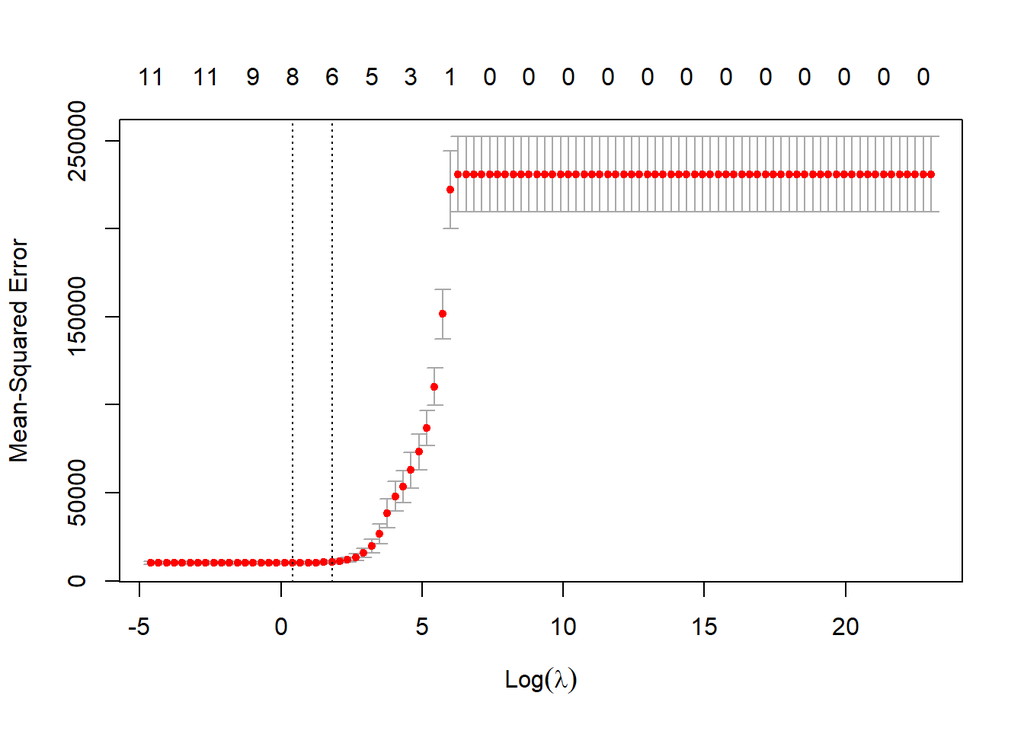

```r
set.seed(1)
cv.out <- cv.glmnet(x[train,], y[train], alpha=1, lambda=grid)
plot(cv.out)
```

```r
bestlam <- cv.out$lambda.min
bestlam
```

```
## [1] 1.519911
```

```r
lasso.pred <- predict(lasso.mod, s=bestlam, newx=x[test,])
mean((lasso.pred - y.test)^2)
```

```
## [1] 10518.35
```

En iyi `lambda` ile kurulan model:

```r
# out <- glmnet(x,y,alpha=1,lambda=grid)
out <- glmnet(x,y,alpha=1)
lasso.coef <- predict(out, type="coefficients", s=bestlam)[1:12,]
lasso.coef
```

```
##        (Intercept)             Income              Limit             Rating
##       -483.4343080         -7.6007750          0.1711165          1.3839377
##              Cards                Age          Education       GenderFemale
##         15.6017715         -0.5638059         -0.5551434         -7.1021432
##         StudentYes         MarriedYes     EthnicityAsian EthnicityCaucasian
##        419.0895716         -5.6051725          8.3482838          2.7633677
```

LASSO modelinde de (bu veri seti için) hiç bir katsayı tam olarak 0 değil.

```r
lasso.coef[lasso.coef!=0]
```

```
##        (Intercept)             Income              Limit             Rating
##       -483.4343080         -7.6007750          0.1711165          1.3839377
##              Cards                Age          Education       GenderFemale
##         15.6017715         -0.5638059         -0.5551434         -7.1021432
##         StudentYes         MarriedYes     EthnicityAsian EthnicityCaucasian
##        419.0895716         -5.6051725          8.3482838          2.7633677
```

Yeterince büyük `lambda` değerleri bazı katsayıların 0 olmasıyla sonuçlanır. Örneğin:

```r
out <- glmnet(x, y, alpha = 1)
lasso.coef <- predict(out, type="coefficients", s=10)[1:12,]
lasso.coef
```

```
##        (Intercept)             Income              Limit             Rating
##       -469.8929099         -6.4884298          0.1278235          1.7706408
##              Cards                Age          Education       GenderFemale
##          8.1430126         -0.2372500          0.0000000          0.0000000
##         StudentYes         MarriedYes     EthnicityAsian EthnicityCaucasian
##        386.3920701          0.0000000          0.0000000          0.0000000
```

Bu durumda son model evlilik ve etnik köken kuklalarını dışlar:

```r
lasso.coef[lasso.coef!=0]
```

```
##  (Intercept)       Income        Limit       Rating        Cards          Age
## -469.8929099   -6.4884298    0.1278235    1.7706408    8.1430126   -0.2372500
##   StudentYes
##  386.3920701
```

# 3 Örnek

Bu örnek kısmi olarak ISLR ders kitabındaki 8. alıştırmaya (s.262) dayanmaktadır. Önce doğru modelin 3. derece bir polinom olduğu bir veri seti oluşturacağız. Yani doğru model 3 değişken içerecek. Ancak veri setinde 10 değişken olacak. Hangilerinin modele girmesi gerektiğini bilmediğimizi varsayacağız.

## 3.1 Veri setinin simülasyonu

```r
set.seed(99) # for replication
n   <- 400
x   <- rnorm(n, mean=0, sd=1)
eps <- rnorm(n, mean=0, sd=1)
f   <- 5  +1*x - 2*x^2 - 1*x^3
y   <- f + eps
df <- data.frame(y, x1=x, x2=x^2, x3=x^3, x4=x^4, x5=x^5, x6=x^6,
            x7=x^7, x8=x^8, x9=x^9, x10=x^10)

# df <- data.frame(y, x1=x, x2=x^2, x3=x^3, x4=x^4, x5=x^5, x6=rnorm(n),
#              x7=rnorm(n), x8=rnorm(n), x9=rnorm(n), x10=rnorm(n),
#              x11=runif(n), x12=runif(n), x13=runif(n), x14=runif(n),
#              x15=runif(n))
head(df)
```

```
##          y         x1          x2            x3           x4            x5
## 1 5.817430  0.2139625 0.045779952  0.0097951932 2.095804e-03  4.484235e-04
## 2 5.643896  0.4796581 0.230071926  0.1103558709 5.293309e-02  2.538979e-02
## 3 4.927971  0.0878287 0.007713881  0.0006775002 5.950397e-05  5.226156e-06
## 4 7.489333  0.4438585 0.197010375  0.0874447309 3.881309e-02  1.722752e-02
## 5 4.195846 -0.3628379 0.131651357 -0.0477681045 1.733208e-02 -6.288736e-03
## 6 6.260835  0.1226740 0.015048918  0.0018461114 2.264699e-04  2.778198e-05
##             x6            x7           x8            x9          x10
## 1 9.594581e-05  2.052881e-05 4.392395e-06  9.398077e-07 2.010836e-07
## 2 1.217842e-02  5.841477e-03 2.801912e-03  1.343960e-03 6.446413e-04
## 3 4.590065e-07  4.031395e-08 3.540722e-09  3.109770e-10 2.731271e-11
## 4 7.646581e-03  3.394000e-03 1.506456e-03  6.686532e-04 2.967874e-04
## 5 2.281792e-03 -8.279206e-04 3.004010e-04 -1.089969e-04 3.954820e-05
## 6 3.408127e-06  4.180887e-07 5.128862e-08  6.291782e-09 7.718383e-10
```

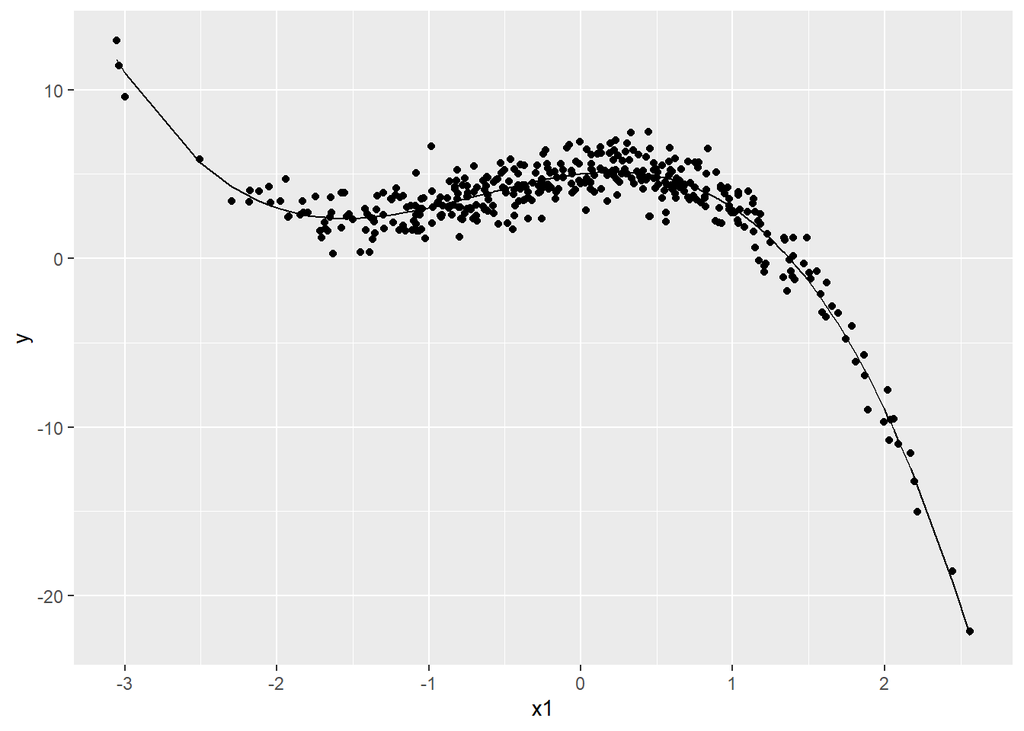

```r
library(ggplot2)
ggplot(df, aes(x=x1,y=y))+
  geom_point() +
  geom_line(aes(x1,f))
```

## 3.2 En iyi altküme seçimi (Best subset selection)

```r
library(leaps)
regfit.full <- regsubsets(y ~ ., data = df, nvmax = 10)
#summary(regfit.full)
```

Veri-bazlı bilgi ölçütleri (Akaike, BIC, Cp, Adj.R2, RSS)

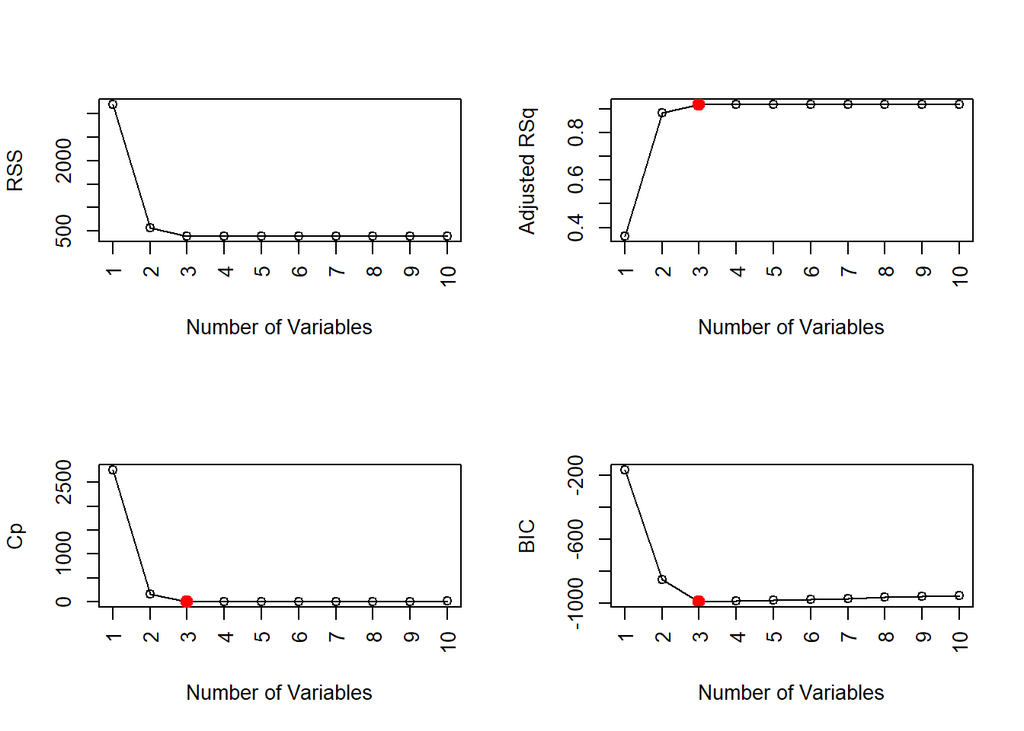

```r
reg.summary <- summary(regfit.full)

# 2x2 plot grid
par(mfrow=c(2,2))
# plot RSS
plot(reg.summary$rss, xlab="Number of Variables", xaxt="n", ylab="RSS", type="o")
axis(1, at = seq(1, 10, by = 1),las=2)

# plot Adj.R2
plot(reg.summary$adjr2, xlab="Number of Variables", xaxt="n", ylab="Adjusted RSq",type="o")
axis(1, at = seq(1, 10, by = 1),las=2)
# find the model with max Adj.R2
best <- which.max(reg.summary$adjr2)
# put red dot on the graph that marks the best according to Adj.R2
points(best, reg.summary$adjr2[best], col="red", cex=2, pch=20)

# plot Cp
plot(reg.summary$cp, xlab="Number of Variables", xaxt="n", ylab="Cp",type='o')
axis(1, at = seq(1, 10, by = 1),las=2)
# find the best according to Cp
bestCp <- which.min(reg.summary$cp)
points(bestCp, reg.summary$cp[bestCp], col="red", cex=2, pch=20)

# plot BICs
plot(reg.summary$bic, xlab="Number of Variables", xaxt="n", ylab="BIC", type='o')
bestBIC <- which.min(reg.summary$bic)
points(bestBIC, reg.summary$bic[bestBIC], col="red", cex=2, pch=20)
axis(1, at = seq(1, 10, by = 1),las=2)
```

```r
regfit.fwd <- regsubsets(y ~ ., data = df, nvmax=10, method="forward")
reg.fwd.summary <- summary(regfit.fwd)
reg.fwd.summary
```

```
## Subset selection object
## Call: regsubsets.formula(y ~ ., data = df, nvmax = 10, method = "forward")
## 10 Variables  (and intercept)
##     Forced in Forced out
## x1      FALSE      FALSE
## x2      FALSE      FALSE
## x3      FALSE      FALSE
## x4      FALSE      FALSE
## x5      FALSE      FALSE
## x6      FALSE      FALSE
## x7      FALSE      FALSE
## x8      FALSE      FALSE
## x9      FALSE      FALSE
## x10     FALSE      FALSE
## 1 subsets of each size up to 10
## Selection Algorithm: forward
##           x1  x2  x3  x4  x5  x6  x7  x8  x9  x10
## 1  ( 1 )  " " " " "*" " " " " " " " " " " " " " "
## 2  ( 1 )  " " "*" "*" " " " " " " " " " " " " " "
## 3  ( 1 )  "*" "*" "*" " " " " " " " " " " " " " "
## 4  ( 1 )  "*" "*" "*" " " "*" " " " " " " " " " "
## 5  ( 1 )  "*" "*" "*" " " "*" " " " " " " "*" " "
## 6  ( 1 )  "*" "*" "*" " " "*" " " "*" " " "*" " "
## 7  ( 1 )  "*" "*" "*" "*" "*" " " "*" " " "*" " "
## 8  ( 1 )  "*" "*" "*" "*" "*" "*" "*" " " "*" " "
## 9  ( 1 )  "*" "*" "*" "*" "*" "*" "*" " " "*" "*"
## 10  ( 1 ) "*" "*" "*" "*" "*" "*" "*" "*" "*" "*"
```

```r
regfit.bwd <- regsubsets(y ~ ., data = df, nvmax=10, method="backward")
reg.bwd.summary <- summary(regfit.bwd)
reg.bwd.summary
```

```
## Subset selection object
## Call: regsubsets.formula(y ~ ., data = df, nvmax = 10, method = "backward")
## 10 Variables  (and intercept)
##     Forced in Forced out
## x1      FALSE      FALSE
## x2      FALSE      FALSE
## x3      FALSE      FALSE
## x4      FALSE      FALSE
## x5      FALSE      FALSE
## x6      FALSE      FALSE
## x7      FALSE      FALSE
## x8      FALSE      FALSE
## x9      FALSE      FALSE
## x10     FALSE      FALSE
## 1 subsets of each size up to 10
## Selection Algorithm: backward
##           x1  x2  x3  x4  x5  x6  x7  x8  x9  x10
## 1  ( 1 )  " " " " "*" " " " " " " " " " " " " " "
## 2  ( 1 )  " " "*" "*" " " " " " " " " " " " " " "
## 3  ( 1 )  "*" "*" "*" " " " " " " " " " " " " " "
## 4  ( 1 )  "*" "*" "*" " " " " " " " " " " "*" " "
## 5  ( 1 )  "*" "*" "*" " " " " " " " " " " "*" "*"
## 6  ( 1 )  "*" "*" "*" " " " " " " " " "*" "*" "*"
## 7  ( 1 )  "*" "*" "*" " " " " "*" " " "*" "*" "*"
## 8  ( 1 )  "*" "*" "*" " " " " "*" "*" "*" "*" "*"
## 9  ( 1 )  "*" "*" "*" " " "*" "*" "*" "*" "*" "*"
## 10  ( 1 ) "*" "*" "*" "*" "*" "*" "*" "*" "*" "*"
```

```r
coef(regfit.full, 3)
```

```
## (Intercept)          x1          x2          x3
##    5.007799    1.051778   -1.996604   -1.008776
```

```r
coef(regfit.fwd, 3)
```

```
## (Intercept)          x1          x2          x3
##    5.007799    1.051778   -1.996604   -1.008776
```

```r
coef(regfit.bwd, 3)
```

```
## (Intercept)          x1          x2          x3
##    5.007799    1.051778   -1.996604   -1.008776
```

Cp ölçütüne göre en iyi model:

```r
coef(regfit.full, which.min(reg.summary$cp))
```

```
## (Intercept)          x1          x2          x3
##    5.007799    1.051778   -1.996604   -1.008776
```

```r
coef(regfit.fwd, which.min(reg.fwd.summary$cp))
```

```
## (Intercept)          x1          x2          x3
##    5.007799    1.051778   -1.996604   -1.008776
```

```r
coef(regfit.bwd, which.min(reg.bwd.summary$cp))
```

```
## (Intercept)          x1          x2          x3
##    5.007799    1.051778   -1.996604   -1.008776
```

BIC ölçütüne göre en iyi model:

```r
coef(regfit.full, which.min(reg.summary$bic))
```

```
## (Intercept)          x1          x2          x3
##    5.007799    1.051778   -1.996604   -1.008776
```

```r
coef(regfit.fwd, which.min(reg.fwd.summary$bic))
```

```
## (Intercept)          x1          x2          x3
##    5.007799    1.051778   -1.996604   -1.008776
```

```r
coef(regfit.bwd, which.min(reg.bwd.summary$bic))
```

```
## (Intercept)          x1          x2          x3
##    5.007799    1.051778   -1.996604   -1.008776
```

Adj. R2 ölçütüne göre en iyi model:

```r
coef(regfit.full, which.max(reg.summary$adjr2))
```

```
## (Intercept)          x1          x2          x3
##    5.007799    1.051778   -1.996604   -1.008776
```

```r
coef(regfit.fwd, which.max(reg.fwd.summary$adjr2))
```

```
## (Intercept)          x1          x2          x3
##    5.007799    1.051778   -1.996604   -1.008776
```

```r
coef(regfit.bwd, which.max(reg.bwd.summary$adjr2))
```

```
## (Intercept)          x1          x2          x3
##    5.007799    1.051778   -1.996604   -1.008776
```

## 3.3 LASSO ve çapraz geçerleme

```r
x <- model.matrix(y ~ ., df)[,-1]
y <- df$y
```

```r
set.seed(666)
train <- sample(1:nrow(x), nrow(x)/2)
test <- (-train)
y.test <- y[test]
```

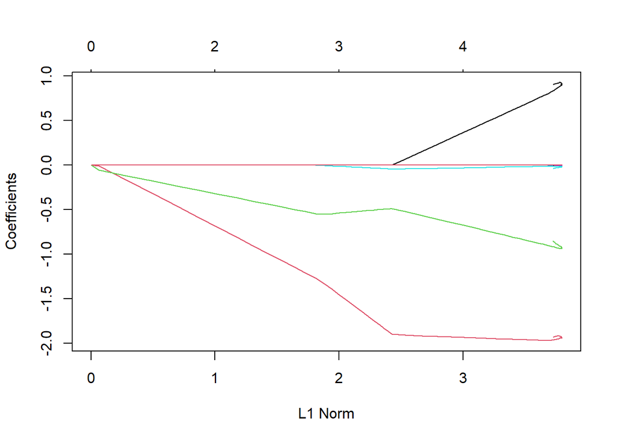

```r
library(glmnet)
lasso.mod <- glmnet(x[train,], y[train], alpha=1)
plot(lasso.mod)
```

`lambda` için çapraz geçerleme:

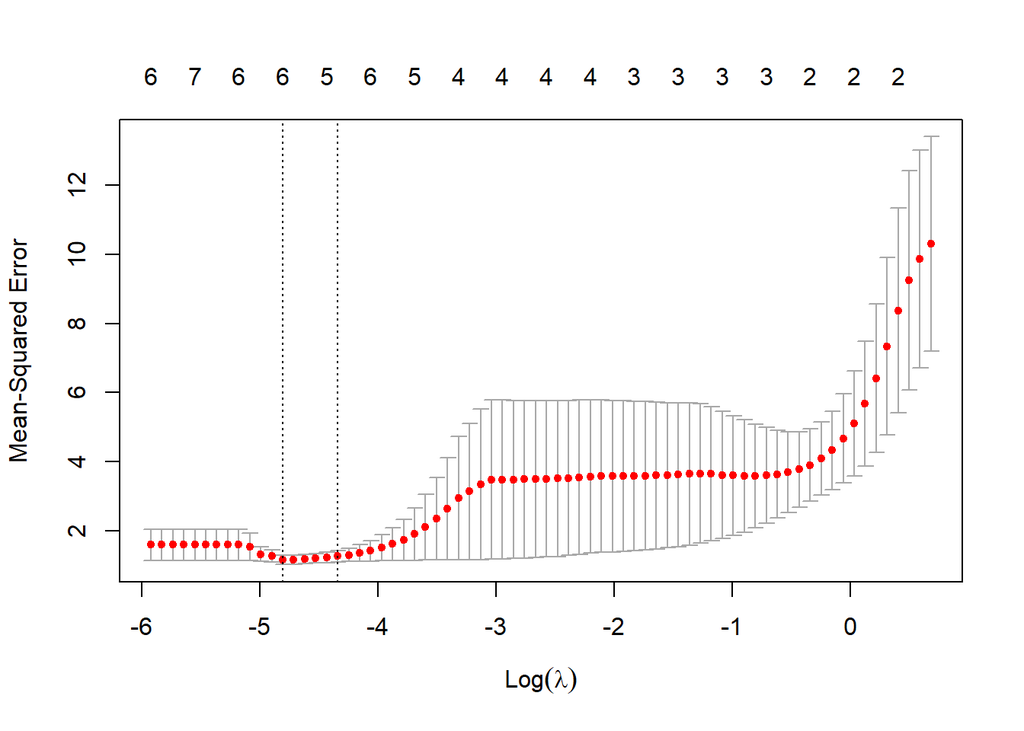

```r
set.seed(1)
cv.out <- cv.glmnet(x[train,], y[train], alpha=1)
plot(cv.out)
```

```r
bestlam <- cv.out$lambda.min
bestlam
```

```
## [1] 0.00817102
```

```r
lasso.pred <- predict(lasso.mod, s=bestlam, newx=x[test,])
mean((lasso.pred - y.test)^2)
```

```
## [1] 0.9984801
```

x4-x10 değişkenlerinin katsayılarının tümü sıfırdır:

```r
out <- glmnet(x,y,alpha=1)
lasso.coef <- predict(out, type="coefficients", s=bestlam)[1:11,]
lasso.coef
```

```
## (Intercept)          x1          x2          x3          x4          x5
##   4.9951622   1.0081146  -1.9844867  -0.9959831   0.0000000   0.0000000
##          x6          x7          x8          x9         x10
##   0.0000000   0.0000000   0.0000000   0.0000000   0.0000000
```

```r
# sprintf("%.5f",lasso.coef[lasso.coef!=0])
lasso.coef[abs(lasso.coef)>0.0001]
```

```
## (Intercept)          x1          x2          x3
##   4.9951622   1.0081146  -1.9844867  -0.9959831
```

## 3.4 Elastic Net

$\alpha=0.5$ olarak belirleyip `glmnet()` fonksiyonunu çalıştıralım:

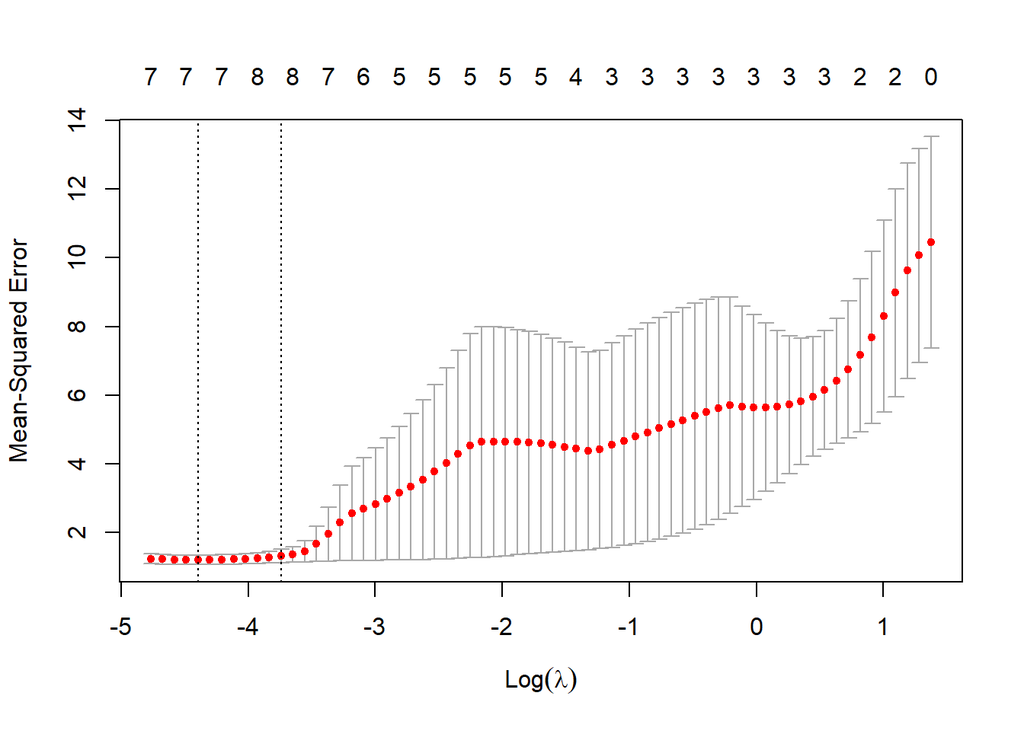

```r
set.seed(1)
cv.out <- cv.glmnet(x[train,], y[train], alpha=0.5)
plot(cv.out)
```

```r
bestlam <- cv.out$lambda.min
bestlam
```

```
## [1] 0.01236215
```

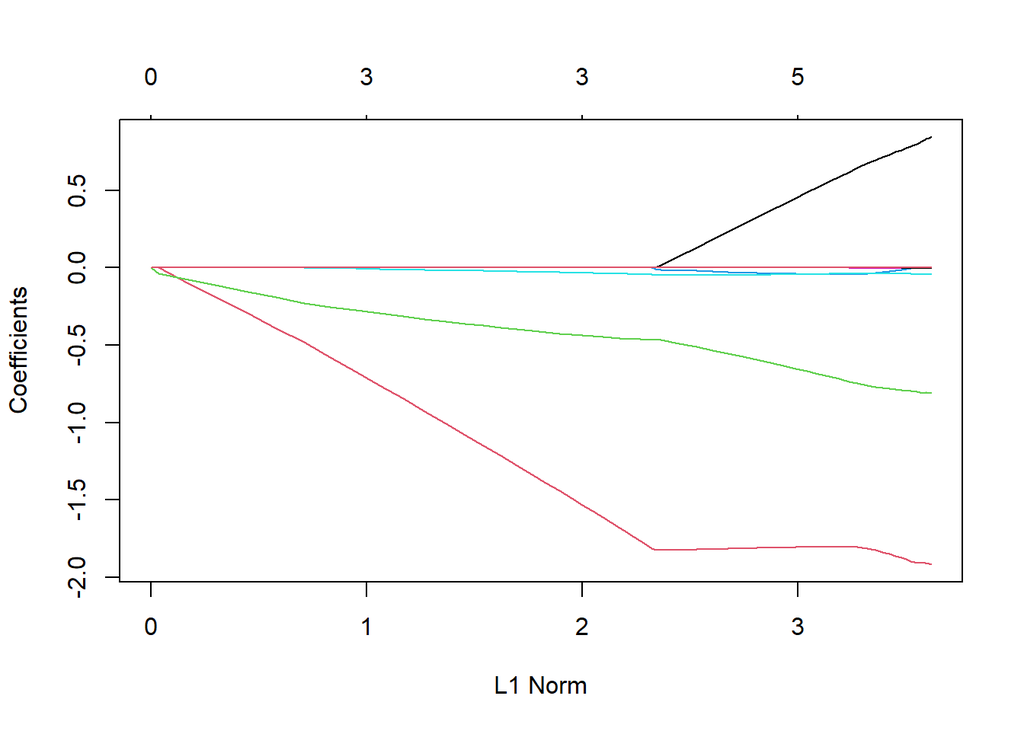

```r
elnet.mod <- glmnet(x[train,], y[train], alpha=0.5)
plot(elnet.mod)
```

```r
elnet.pred <- predict(lasso.mod, s=bestlam, newx=x[test,])
mean((elnet.pred - y.test)^2)
```

```
## [1] 0.9784411
```

Hangi katsayılar tam olarak sıfırdır?

```r
out <- glmnet(x, y, alpha=1)
lasso.coef <- predict(out, type="coefficients", s=bestlam)[1:11,]
lasso.coef
```

```
## (Intercept)          x1          x2          x3          x4          x5
##   4.9888401   0.9864748  -1.9784137  -0.9895979   0.0000000   0.0000000
##          x6          x7          x8          x9         x10
##   0.0000000   0.0000000   0.0000000   0.0000000   0.0000000
```

```r
MSE <- numeric(11)
lambda <- rep(NA, 11)
alpha <-  (0:10)/10
set.seed(1)
for (i in 1:11) {
  fit <- cv.glmnet(x[train,], y[train], type.measure="mse",
                                              alpha=alpha[i], family="gaussian")
  yhat <- predict(fit, s=fit$lambda.1se, newx=x[test,])
  lambda[i] <- fit$lambda.1se
  MSE[i] <- mean((y[test] - yhat)^2)
}
```

Yukarıdaki döngüde her bir $\alpha$ değeri için CV ile $\lambda$ değeri belirlendi. Sonuçlar:

```r
cbind(alpha, lambda, MSE)
```

```
##       alpha     lambda       MSE
##  [1,]   0.0 2.93651234 3.1240702
##  [2,]   0.1 0.02024024 1.1595783
##  [3,]   0.2 0.01218972 1.1203282
##  [4,]   0.3 0.03600536 1.0688107
##  [5,]   0.4 0.02700402 1.0512317
##  [6,]   0.5 0.02855818 1.0239753
##  [7,]   0.6 0.02866536 1.0028133
##  [8,]   0.7 0.03564731 0.9893176
##  [9,]   0.8 0.03757014 0.9819981
## [10,]   0.9 0.03042890 0.9715583
## [11,]   1.0 0.03005611 0.9692169
```

En küçük MSE değeri alpha=1 olduğunda (yani LASSO ile) sağlanıyor.

# 4 Uygulama: Ekonomik büyümenin belirleyicileri

Bu örnekte Barro-Lee (1994) büyüme verilerini kullanacağız. Bu veriler `hdm` paketinin bir parçasıdır, bkz. [Belloni et al., hdm: High-Dimensional Metrics](https://journal.r-project.org/archive/2016/RJ-2016-040/RJ-2016-040.pdf)

```r
# install.packages("hdm")
library(hdm)
```

Veri seti:

```r
data("GrowthData")
```

Veri setinde $n=90$ ülke ve $p=60$ makroekonomik gösterge ve diğer ülke özellikleri yer almaktadır.

Standart ekonomik yakınsama modeli aşağıdaki gibi yazılabilir:
$$Y_{i,T}=\beta_{0}+\beta_{1} Y_{i,0}+\sum_{j=2}^{p} \beta_{j} X_{i j}+\varepsilon_{i},\quad i=1,\dots,n,$$
Burada $Y_{i,T}$ kişi başına GDP’nin büyüme oranı (1965-1975 ve 1975-1985 dönemleri için), $Y_{i,0}$ $i$ ülkesi için başlangıç gelir düzeyi, $X_{i j}$ ise ülkelerin büyüme performansını etkileyebilecek değişkenlerden oluşmaktadır. Yakınsama hipotezi: $\beta_1<0$.

İktisat teorisi modelde yer alması gereken değişkenlerin hangileri olması gerektiği konusunda çok açık değildir. Acaba LASSO benzeri düzenlileştirme yaklaşımlarını kullanabilir miyiz?

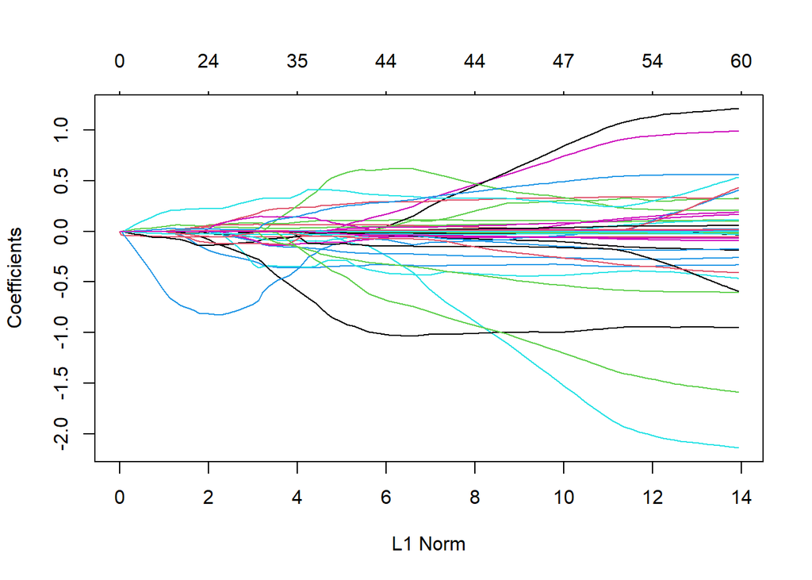

```r
# standard lasso using glmnet
y <- GrowthData$Outcome
x <- model.matrix(Outcome ~ . -intercept, data=GrowthData)[,-1]
library(glmnet)
lasso_fit1 <- glmnet(x, y, alpha=1)
plot(lasso_fit1)
```

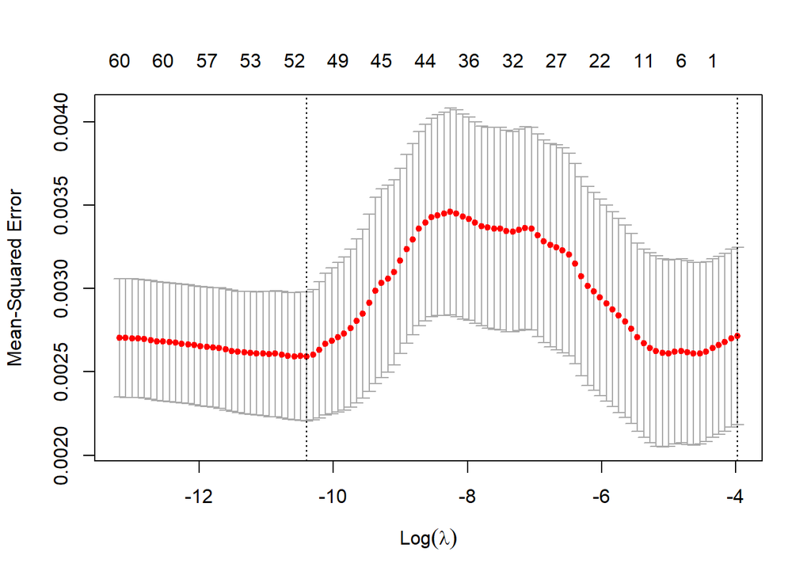

```r
cv.out <- cv.glmnet(x, y, alpha=1)
plot(cv.out)
```

```r
bestlam <- cv.out$lambda.min
bestlam
```

```
## [1] 3.050841e-05
```

```r
out <- glmnet(x, y, alpha=1, lambda=bestlam)
coefficients(out)
```

```
## 62 x 1 sparse Matrix of class "dgCMatrix"
##                        s0
## (Intercept)  9.502145e-01
## gdpsh465    -2.251857e-03
## bmp1l       -5.751675e-02
## freeop       1.039681e-01
## freetar     -3.447043e-01
## h65         -1.893088e+00
## hm65         8.963261e-01
## hf65         1.056803e+00
## p65          3.355455e-01
## pm65         9.431682e-02
## pf65        -2.733082e-01
## s65          5.625479e-02
## sm65        -7.487775e-02
## sf65        -1.441654e-01
## fert65      -1.094875e-02
## mort65       2.394424e-01
## lifee065    -1.776998e-01
## gpop1       -3.934365e-01
## fert1        1.426031e-02
## mort1       -9.507152e-01
## invsh41      9.337134e-03
## geetot1      3.256478e-01
## geerec1      .
## gde1         2.438063e-01
## govwb1       1.223166e-01
## govsh41     -1.753571e-01
## gvxdxe41     .
## high65       .
## highm65      6.401939e-04
## highf65     -4.512413e-03
## highc65      .
## highcm65     1.425886e-02
## highcf65    -1.840872e-02
## human65      .
## humanm65    -6.829672e-03
## humanf65     1.246143e-02
## hyr65        .
## hyrm65       4.492256e-02
```

[output cut: 9 more lines]

```
## sec65        .
## secm65      -5.741042e-03
## secf65       2.352343e-03
## secc65       .
## seccm65      1.381822e-02
## seccf65     -1.764522e-02
## syr65        .
## syrm65       .
## syrf65       1.030268e-01
## teapri65    -4.492751e-04
## teasec65    -9.301841e-06
## ex1         -5.744466e-01
## im1          5.363024e-01
## xr65        -4.030031e-05
## tot1        -6.570651e-02
```

Bu amaçla Belloni, Chernozhukov, ve Hansen tarafından geliştirilen **Post-Double Selection LASSO** yaklaşımını kullanabiliriz. Bu algoritma aşağıdaki adımlardan oluşur:

Step 1: Use LASSO (or other shrinkage methods) to select $x_j$ for predicting $y_T$.

Step 2: Use LASSO (or other shrinkage methods) to select $x_j$ for predicting $y_0$.

Step 3: Refit the model by OLS after selection (use either $x_j$ selected in both steps)

Daha fazla detay için bkz. [How to do model selection with inference in mind](https://stuff.mit.edu/~vchern/papers/Chernozhukov-Saloniki.pdf).

```r
# prepare data
library(hdm)
yT <- GrowthData$Outcome
y0 <- GrowthData$gdpsh465
x <- model.matrix(Outcome ~ . -intercept -gdpsh465 , data=GrowthData)[,-1]
```

```r
double_lasso_fit <- rlassoEffect(x = x, y = yT, d = y0,
                      method = "double selection")
summary(double_lasso_fit)
```

```
## [1] "Estimates and significance testing of the effect of target variables"
##    Estimate. Std. Error t value Pr(>|t|)
## d1  -0.05001    0.01579  -3.167  0.00154 **
## ---
## Signif. codes:  0 '***' 0.001 '**' 0.01 '*' 0.05 '.' 0.1 ' ' 1
```

```r
# Selected coefficients
 double_lasso_fit$coefficients.reg
```

```
##   (Intercept)           xd1        xbmp1l      xfreetar         xhm65
## -0.4064512995 -0.0500058545 -0.0782423426 -0.5746764184  0.0511528988
##         xsf65     xlifee065     xhumanf65      xpop6565
## -0.0470218317  0.2122793760 -0.0003760384  0.1343892586
```

Başlangıç gelir düzeyi $Y_0$’ın katsayısı $\hat{\beta}_1=-0.05$ ve değişen-varyans dirençli standart hatası 0.016 olarak tahmin edilmiştir. Bu sonuç neoklasik yakınsama hipotezini desteklemektedir.

**Kaynaklar**

[A. Belloni, V. Chernozhukov, C. Hansen (2014). Inference on treatment effects after selection among high-dimensional controls. The Review of Economic Studies 81(2), 608-650.](https://www.jstor.org/stable/pdf/43551575.pdf?refreqid=excelsior%3A2d94601a4e1a0bc9e93644a411795bb8)